# Análisis de Datos de Fútbol — Caso Práctico

## Transición entre Modelo de Regresión y ANOVA

- Luego de entrenar y evaluar el modelo de regresión y obtener métricas de desempeño como el R-cuadrado y el RMSE, se complementa analizando cómo varían los goles según la posición de los jugadores.
- La regresión permite cuantificar la relación entre variables continuas y categóricas, pero un análisis más específico sobre la diferencia promedio de goles entre posiciones requiere aplicar técnicas de comparación de medias. Se realiza el Análisis de Varianza (ANOVA) seguido de la prueba de comparaciones múltiples de Tukey.
- Se busca determinar si existen diferencias estadísticamente significativas en la capacidad goleadora entre las distintas posiciones, al identificar qué posiciones concretas difieren entre sí, más allá de lo que el modelo de regresión pueda indicar.
- Se complementa la interpretación del modelo con hallazgos más intuitivos y visuales, para presentar resultados a públicos variados (entrenadores, analistas deportivos o aficionados).
- El ANOVA/Tukey se integra de forma natural dentro del flujo de análisis, después de evaluar el modelo predictivo y antes de profundizar en conclusiones finales sobre el desempeño de los jugadores.

# 🧩 Paso 6 — ANOVA y Comparaciones entre Posiciones (Integrado)

## Ajuste de ANOVA

```r
# ANOVA: Goles según posición
anova_goles <- aov(goles ~ posicion, data = df)
summary(anova_goles)
```

```
             Df Sum Sq Mean Sq F value Pr(>F)
posicion      9   1372  152.46      19 <2e-16 ***
Residuals   572   4589    8.02
---
Signif. codes:  0 ‘***’ 0.001 ‘**’ 0.01 ‘*’ 0.05 ‘.’ 0.1 ‘ ’ 1
```

## Comparación múltiple Tukey

```r
# Comparación múltiple entre todas las posiciones
tukey_goles <- TukeyHSD(anova_goles)

# Mostrar resultados
tukey_goles
```

```
  Tukey multiple comparisons of means
    95% family-wise confidence level

Fit: aov(formula = goles ~ posicion, data = df)

$posicion
                   diff        lwr         upr     p adj
CC_DF-CC     0.25505051 -2.0054420  2.51554301 0.9999984
CC_DL-CC     1.70845552  0.3232994  3.09361161 0.0039425
DF-CC       -0.32664884 -1.3703417  0.71704400 0.9925459
DF_CC-CC    -0.42127800 -2.4540826  1.61152656 0.9997044
DF_DL-CC     0.64393939 -3.1114728  4.39935159 0.9999393
DL-CC        4.00880426  2.7022982  5.31531037 0.0000000
DL_CC-CC     2.22086247  0.7478686  3.69385632 0.0000927
DL_DF-CC    -0.85606061 -5.4220316  3.70991043 0.9998713
PO-CC       -0.80728012 -2.4157940  0.80123378 0.8508245
CC_DL-CC_DF  1.45340502 -0.9553551  3.86216516 0.6578122
DF-CC_DF    -0.58169935 -2.8116686  1.64826989 0.9981232
DF_CC-CC_DF -0.67632850 -3.5075407  2.15488367 0.9990633
DF_DL-CC_DF  0.38888889 -3.8521710  4.62994875 0.9999997
DL-CC_DF     3.75375375  1.3893455  6.11816198 0.0000271
DL_CC-CC_DF  1.96581197 -0.4945089  4.42613286 0.2506170
DL_DF-CC_DF -1.11111111 -6.0841946  3.86197240 0.9994534
PO-CC_DF    -1.06233062 -3.6061044  1.48144315 0.9473073
DF-CC_DL    -2.03510436 -3.3698679 -0.70034079 0.0000717
DF_CC-CC_DL -2.12973352 -4.3262292  0.06676219 0.0661935
DF_DL-CC_DL -1.06451613 -4.9109976  2.78196535 0.9970346
DL-CC_DL     2.30034874  0.7513951  3.84930234 0.0001299
DL_CC-CC_DL  0.51240695 -1.1793407  2.20415455 0.9941439
DL_DF-CC_DL -2.56451613 -7.2056788  2.07664651 0.7630193
PO-CC_DL    -2.51573564 -4.3267067 -0.70476463 0.0005144
DF_CC-DF    -0.09462916 -2.0934365  1.90417818 1.0000000
DF_DL-DF     0.97058824 -2.7665306  4.70770707 0.9981863
DL-DF        4.33545310  3.0824987  5.58840746 0.0000000
DL_CC-DF     2.54751131  1.1218019  3.97322072 0.0000010
DL_DF-DF    -0.52941176 -5.0803488  4.02152528 0.9999979
PO-DF       -0.48063128 -2.0459598  1.08469724 0.9935222
DF_DL-DF_CC  1.06521739 -3.0589864  5.18942117 0.9982630
DL-DF_CC     4.43008226  2.2823173  6.57784720 0.0000000
DL_CC-DF_CC  2.64214047  0.3892208  4.89506011 0.0081163
DL_DF-DF_CC -0.43478261 -5.3085930  4.43902777 0.9999998
PO-DF_CC    -0.38600212 -2.7297711  1.95776685 0.9999569
DL-DF_DL     3.36486486 -0.4539989  7.18372865 0.1392838
DL_CC-DF_DL  1.57692308 -2.3020553  5.45590146 0.9554346
DL_DF-DF_DL -1.50000000 -7.3073104  4.30731039 0.9982624
PO-DF_DL    -1.45121951 -5.3836589  2.48121986 0.9762614
DL_CC-DL    -1.78794179 -3.4159193 -0.15996428 0.0185949
DL_DF-DL    -4.86486486 -9.4831645 -0.24656524 0.0296593
PO-DL       -4.81608438 -6.5676314 -3.06453739 0.0000000
DL_DF-DL_CC -3.07692308 -7.7450538  1.59120761 0.5327928
PO-DL_CC    -3.02814259 -4.9071502 -1.14913500 0.0000185
PO-DL_DF     0.04878049 -4.6638674  4.76142838 1.0000000
```

## Gráfico de Tukey

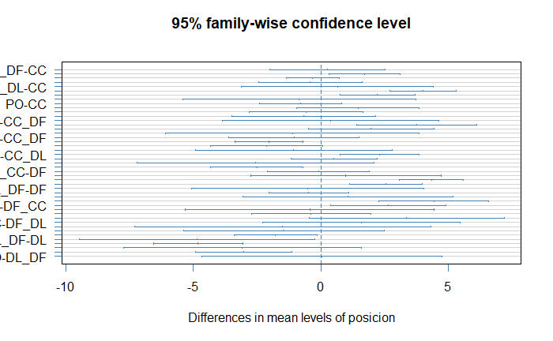

```r
plot(tukey_goles, las=1, col="steelblue")
```

### Conlusiones ANOVA/Tukey:

#### ANOVA

- Valor F = 19 y p < 2e-16 → Rechazamos H₀.
- Existe diferencias estadísticamente significativa en goles promedio entre al menos dos posiciones.

# 🧠 Paso 7 — Evaluación y diagnóstico Visual del Modelo de Regresión

## Introducción

Se realiza evaluación visual de los resultados del modelo de regresión múltiple ajustado en el paso anterior.  
Se analizan tres gráficos de diagnóstico clásicos:  
(1) Ajuste del modelo, (2) Homocedasticidad y (3) Normalidad de los residuos.

## 🧠 Gráficas explicativas

#### 1️⃣ Gráfico de Valores Reales vs. Predichos

Para ver qué tan cerca están las predicciones del modelo de los valores reales de goles. Una buena regresión debe indicar puntos alineados a la diagonal (línea roja).

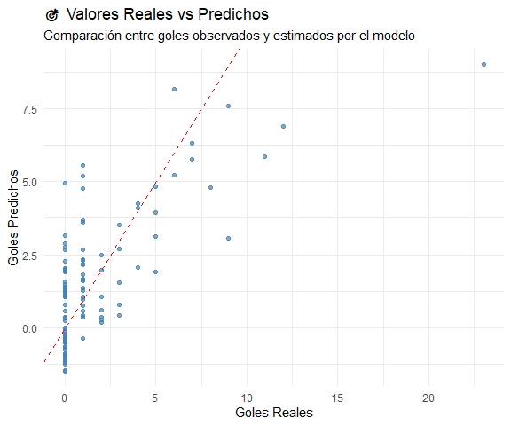

```r
predicciones <- data.frame(
  Real = test_data$goles,
  Predicho = predict(modelo, newdata = test_data)
)

ggplot(predicciones, aes(x = Real, y = Predicho)) +
  geom_point(alpha = 0.7, color = "steelblue") +
  geom_abline(slope = 1, intercept = 0, color = "red", linetype = "dashed") +
  labs(
    title = "🎯 Valores Reales vs Predichos",
    subtitle = "Comparación entre goles observados y estimados por el modelo",
    x = "Goles Reales",
    y = "Goles Predichos"
  ) +
  theme_minimal()
```

#### 2️⃣ Gráfico de **Residuos vs. Predicciones**

Para comprobar si los errores del modelo (residuos) son aleatorios.  
Si se observa una nube difusa sin patrón claro, el modelo es consistente.  
Si se muestra una forma curva o cono, el modelo puede tener problemas de ajuste.

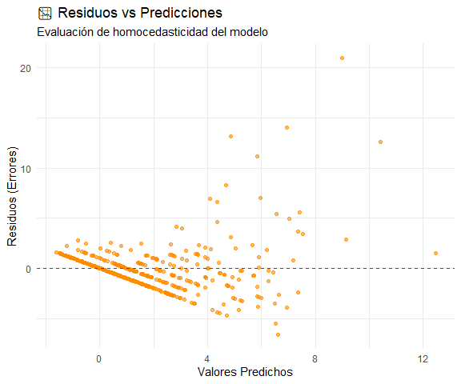

```r
residuos <- resid(modelo)
predichos <- predict(modelo)

ggplot(data.frame(predichos, residuos), aes(x = predichos, y = residuos)) +
  geom_point(alpha = 0.6, color = "darkorange") +
  geom_hline(yintercept = 0, color = "red", linetype = "dashed") +
  labs(
    title = "📉 Residuos vs Predicciones",
    subtitle = "Evaluación de homocedasticidad del modelo",
    x = "Valores Predichos",
    y = "Residuos (Errores)"
  ) +
  theme_minimal()
```

#### 3️⃣ Histograma o **Gráfico QQ de Residuos**

Verifica si los errores del modelo se distribuyen normalmente (supuesto de regresión lineal).

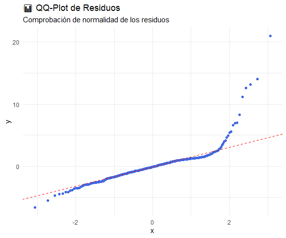

```r
ggplot(data.frame(residuos), aes(sample = residuos)) +
  stat_qq(color = "royalblue") +
  stat_qq_line(color = "red", linetype = "dashed") +
  labs(
    title = "📊 QQ-Plot de Residuos",
    subtitle = "Comprobación de normalidad de los residuos"
  ) +
  theme_minimal()
```